# Social Network Analysis Project

## Sai Dheeraj Kanaparthi (DJ)

## Question:

The CommitteeEMail.csv file documents 129 email communications for a particular committee assignment over a three-month period and involving a total of 29 people. The file provides you with information on who each email was From, whom the email was directed To, and the Date of the email. The Members.csv file notes the Discipline and Role of each Person participating in the communications. Disciplines are BUSiness or NON-business. Roles include Faculty, Staff, and Administrator. Write the R code to complete the following tasks to analyze the network underlying the email communications.

### Loading Libraries:

```r
library(igraph)
```

## Loading Members.csv or the vertices:

```r
#open file containing members attribute information
Members=read.csv("D:/Downloads/MBAN/Completed Subjects/MIS 668A/Project/Members_ProjQs3.csv", header=T)
#understand the data
View(Members)               #examine the data
```

## Plotting the Role distribution:

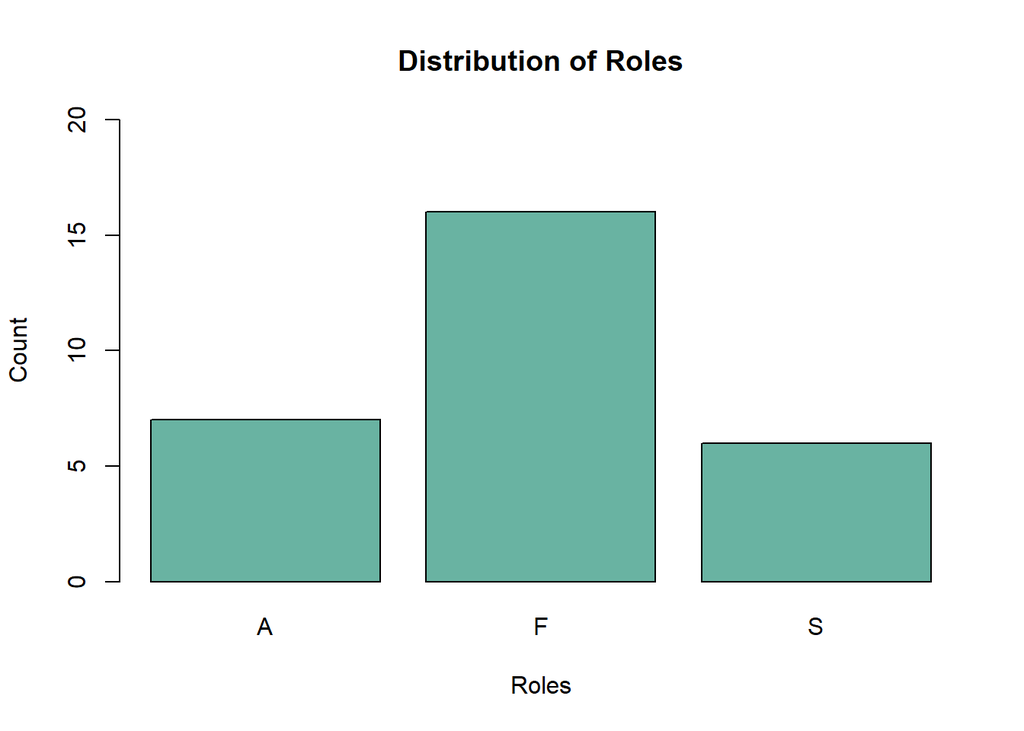

```r
barplot(table(Members$Role), main = "Distribution of Roles", col="#69b3a2", xlab = "Roles", ylab = "Count", ylim = c(0,20))
```

- We see that there are a large number of faculties, followed by Administrator and then Staff.

## Determine the number of BUSiness and NON-BUSiness by Roles:

```r
table(Members$Role, Members$Discipline)
```

```
##
##     BUS NON
##   A   5   2
##   F  16   0
##   S   4   2
```

- We see that:
- There are $5$ *Administrators* that are from the *Business* background, $2$ from *Non-business* background.
- There are $16$ *Faculties* that are from the *Business* background and none from the non-business background.
- There are $4$ *Staff* members that are from the *Business* background, $2$ from *Non-business* background.

## Open file containing Members edge list – Committee.csv:

```r
Committee=read.csv('D:/Downloads/MBAN/Completed Subjects/MIS 668A/Project/CommitteeEMail_ProjQs3.csv', header=T, stringsAsFactors = F)
View(Committee)
```

## Creating and Inspecting the Committee Graph Data Object:

```r
#create graph from edge list, specifying graph as directed
CommitteeGraph=graph_from_data_frame(Committee, directed=T, vertices=Members)
```

## Checking for Self-Loops within the graph:

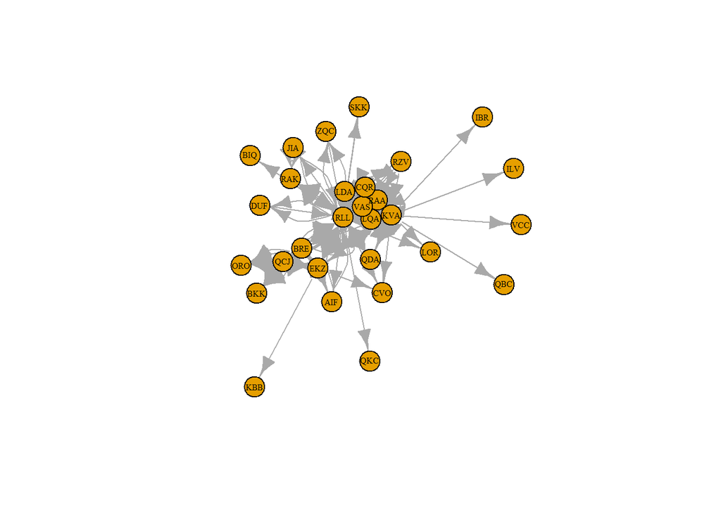

```r
plot(CommitteeGraph, layout=layout.fruchterman.reingold,
     vertex.label.color='black',
     vertex.label.cex=0.5)
```

- We observe that there are self-loops present in the graph.

## Simplifying Graph (Removing self-loops):

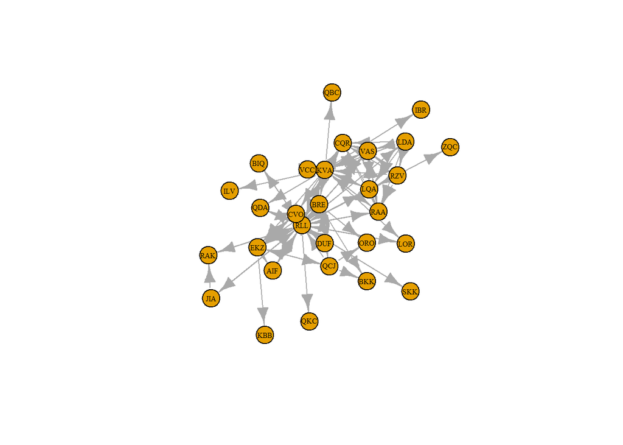

```r
CSG=simplify(CommitteeGraph)

plot(CSG, layout=layout.drl(CSG),
     vertex.label.color='black',
     vertex.label.cex=0.5)
```

## Question 3(b): Depicting BUSiness members in Blue, NON-business in Yellow in the Graph:

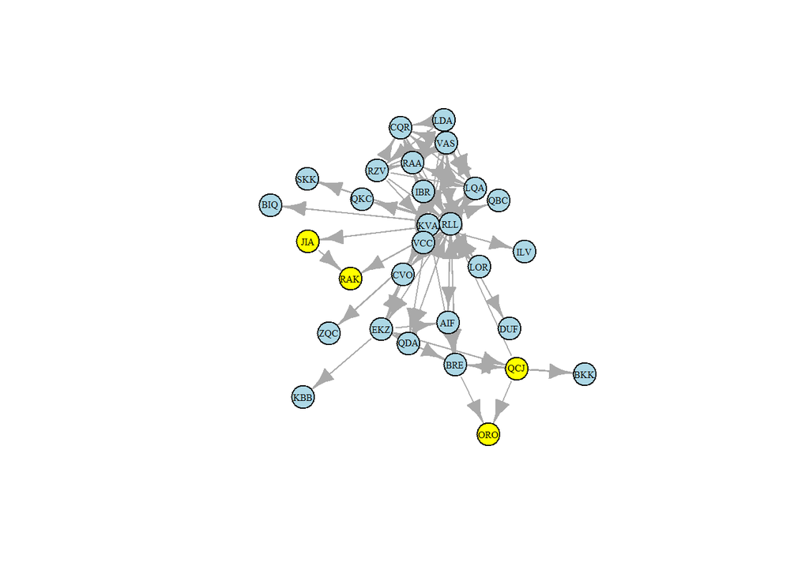

```r
plot(CSG, layout=layout.drl(CSG),
     vertex.color = ifelse(V(CSG)$Discipline=='BUS', 'lightblue','yellow'),
     vertex.label.color='black',
     vertex.label.cex=0.5)
```

## Question 3(c):

### Depicting Faculties members in Blue, Administrators in Yellow and Staff members in Green, in the Graph:

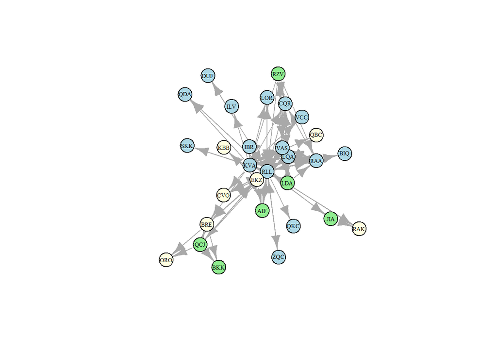

```r
plot(CSG, layout=layout.drl(CSG),
    vertex.color = ifelse(V(CSG)$Role=='F','lightblue',ifelse(V(CSG)$Role=='A','lightyellow','lightgreen')),
    vertex.label.color='black',
    vertex.label.cex=0.5)
```

### Calculating Homophily Index based on Roles:

```r
#Homophily Index based on Degree Centrality
assortativity_degree(CSG, directed=T)
```

```
## [1] -0.5457247
```

```r
# Homophily Index based on Discipline
assortativity.nominal(CSG,as.factor(Members$Discipline), directed = T)
```

```
## [1] 0.1995094
```

```r
# Homophily Index based on Roles
assortativity.nominal(CSG,as.factor(Members$Role), directed = T)
```

```
## [1] 0.1641127
```